# Chapter 9 - Functional Annotation and Enrichment Analysis

Sasha Ajay Malkani

2026-01-05

## 1. Functional Annotation and Enrichment Analysis

In this chapter, we will explore various tools and strategies in R to perform functional annotation and enrichment analysis, which allows researcher to determine whether a set of genes or proteins shows statistically significant differences in their functional characteristics.

**Objectives**

- Understand the concept of functional annotation.
- Learn how to utilize R packages for functional annotation.
- Perform gene set enrichment analysis (GSEA) to identify over-represented biological terms in a list of genes.
- Visualize the results of enrichment analysis.

### 1. A. R Package for Functional Annotation

Several packages can assist in functional annotation and enrichment analyses. Some of the most widely used packages include:

- **biomaRt**: This package provides an interface to the BioMart database, allowing retrival of annotations based on gene identifiers.
- **clusterProfiler**: A comprehensive package for statistical analysis and visualization of functional profiles for genes and gene clusters.
- **GeneAnswers**: Used for group testing of gene sets and the identification of significant enrichment.
- **AnnotationDbi**: Offers a framework to access Bioconductor annotation resources.

### 1. B. Getting Started with Bioconductor

To leverage the capabilities of R for bioinformatics, you first need to install and load the necessary Bioconductor packages. Install Bioconductor and relevant packages as follows:

#### 1. B. I. Installing Bioconductor

```r
# if (!require("BiocManager", quietly = TRUE))
#   install.packages("BiocManager")
# BiocManager::install(version = "3.22")

# BiocManager::install(c("biomaRt", "clusterProfiler", "AnnotationDbi"))
```

#### 1. B. II. Load the Packages

After installation, you can load the packages with:

```r
library(biomaRt)
library(clusterProfiler)
library(AnnotationDbi)
```

### 1. C. Performing Functional Annotation

#### 1. C. I. Step 1: Retrieving Gene Annotations

Using “biomaRt”, you can obtain functional annotations for given set of genes. For example, to retrieve gene annotations from the Ensembl database:

```r
# Define the attributes and filters
attributes <- c("ensembl_gene_id",
                "external_gene_name",
                "description",
                "gene_biotype")
attributes
```

```
## [1] "ensembl_gene_id"    "external_gene_name" "description"
## [4] "gene_biotype"
```

```r
filters <- "ensembl_gene_id"
filters
```

```
## [1] "ensembl_gene_id"
```

```r
# Connect to BioMart and retrieve annotations
mart <- useEnsembl(biomart = "ensembl", dataset = "hsapiens_gene_ensembl")
mart
```

```
## Object of class 'Mart':
##   Using the ENSEMBL_MART_ENSEMBL BioMart database
##   Using the hsapiens_gene_ensembl dataset
```

```r
genes_of_interest <- c("ENSG00000139618", "ENSG00000171862") # Example gene IDs
genes_of_interest
```

```
## [1] "ENSG00000139618" "ENSG00000171862"
```

```r
annotations <- getBM(attributes = attributes, filters = filters,
                     values = genes_of_interest, mart = mart)

print(annotations)
```

```
##   ensembl_gene_id external_gene_name
## 1 ENSG00000139618              BRCA2
## 2 ENSG00000171862               PTEN
##                                                         description
## 1    BRCA2 DNA repair associated [Source:HGNC Symbol;Acc:HGNC:1101]
## 2 phosphatase and tensin homolog [Source:HGNC Symbol;Acc:HGNC:9588]
##     gene_biotype
## 1 protein_coding
## 2 protein_coding
```

This will give you a data frame containing the gene IDs, their external names, descriptions, and biotypes.

### 1. D. Gene Set Enrichment Analysis

#### 1. D. I. Step 1: Preparing Data

To perform gene set enrichment analysis, you need a ranked list of genes, typically based on their expression levels or another relevant metric, along with a predefined set of gene annotations (like KEGG pathways, GO terms, etc.)

#### 1. D. II.: Running Enrichment Analysis with clusterProfiler

Using the “clusterProfiler” package, you can conduct enrichment analysis for Gene Ontology (GO) terms, KEGG pathways, and more.

```r
# Load library
library(org.Hs.eg.db)
# Sample data
gene_list <- c(annotations$external_gene_name) # Replace with your gene list
gene_list
```

```
## [1] "BRCA2" "PTEN"
```

```r
# Simulated logFC values for the gene list (normally you would get these from
# your analysis).
logFC <- rnorm(length(gene_list))
logFC
```

```
## [1] -0.7121939 -1.0546005
```

```r
names(logFC) <- gene_list
names(logFC)
```

```
## [1] "BRCA2" "PTEN"
```

```r
# Enrichment analysis for GO terms
ego <- enrichGO(gene = names(logFC)[abs(logFC) > 0.1], OrgDb = org.Hs.eg.db,
                keyType = "SYMBOL", ont = "BP", pAdjustMethod = "BH",
                qvalueCutoff = 0.05)
ego
```

```
## #
## # over-representation test
## #
## #...@organism     Homo sapiens
## #...@ontology     BP
## #...@keytype      SYMBOL
## #...@gene     chr [1:2] "BRCA2" "PTEN"
## #...pvalues adjusted by 'BH' with cutoff <0.05
## #...302 enriched terms found
## 'data.frame':    302 obs. of  12 variables:
##  $ ID            : chr  "GO:0090398" "GO:0007292" "GO:0140013" "GO:1903046" ...
##  $ Description   : chr  "cellular senescence" "female gamete generation" "meiotic nuclear division" "meiotic cell cycle process" ...
##  $ GeneRatio     : chr  "2/2" "2/2" "2/2" "2/2" ...
##  $ BgRatio       : chr  "111/18860" "176/18860" "203/18860" "227/18860" ...
##  $ RichFactor    : num  0.01802 0.01136 0.00985 0.00881 0.0073 ...
##  $ FoldEnrichment: num  169.9 107.2 92.9 83.1 68.8 ...
##  $ zScore        : num  18.4 14.6 13.6 12.8 11.6 ...
##  $ pvalue        : num  3.43e-05 8.66e-05 1.15e-04 1.44e-04 2.10e-04 ...
##  $ p.adjust      : num  0.0104 0.011 0.011 0.011 0.0113 ...
##  $ qvalue        : num  7.23e-05 7.59e-05 7.59e-05 7.59e-05 7.82e-05 ...
##  $ geneID        : chr  "BRCA2/PTEN" "BRCA2/PTEN" "BRCA2/PTEN" "BRCA2/PTEN" ...
##  $ Count         : int  2 2 2 2 2 2 2 2 2 2 ...
## #...Citation
## S Xu, E Hu, Y Cai, Z Xie, X Luo, L Zhan, W Tang, Q Wang, B Liu, R Wang, W Xie, T Wu, L Xie, G Yu. Using clusterProfiler to characterize multiomics data. Nature Protocols. 2024, 19(11):3292-3320
```

```r
# View results
head(ego)
```

```
##                    ID                                        Description
## GO:0090398 GO:0090398                                cellular senescence
## GO:0007292 GO:0007292                           female gamete generation
## GO:0140013 GO:0140013                           meiotic nuclear division
## GO:1903046 GO:1903046                         meiotic cell cycle process
## GO:1901988 GO:1901988 negative regulation of cell cycle phase transition
## GO:0051321 GO:0051321                                 meiotic cell cycle
##            GeneRatio   BgRatio  RichFactor FoldEnrichment   zScore       pvalue
## GO:0090398       2/2 111/18860 0.018018018      169.90991 18.38036 3.432854e-05
## GO:0007292       2/2 176/18860 0.011363636      107.15909 14.57153 8.659451e-05
## GO:0140013       2/2 203/18860 0.009852217       92.90640 13.55812 1.152888e-04
## GO:1903046       2/2 227/18860 0.008810573       83.08370 12.81312 1.442361e-04
## GO:1901988       2/2 274/18860 0.007299270       68.83212 11.64781 2.103066e-04
## GO:0051321       2/2 299/18860 0.006688963       63.07692 11.14273 2.505112e-04
##              p.adjust       qvalue     geneID Count
## GO:0090398 0.01043588 7.227061e-05 BRCA2/PTEN     2
## GO:0007292 0.01096194 7.591373e-05 BRCA2/PTEN     2
## GO:0140013 0.01096194 7.591373e-05 BRCA2/PTEN     2
## GO:1903046 0.01096194 7.591373e-05 BRCA2/PTEN     2
## GO:1901988 0.01129331 7.820852e-05 BRCA2/PTEN     2
## GO:0051321 0.01129331 7.820852e-05 BRCA2/PTEN     2
```

```r
# Load library
# library(enrichplot)
# library(clusterProfiler)

# Check if results exist
# if (!is.null(ego) && nrow(as.data.frame(ego)) > 0) {
#   library(enrichplot)
#   library(ggplot2)

#   dotplot(ego, showCategory = 10) +
#     ggtitle("Top 10 Enriched GO Terms")
# } else {
#   message("No significant GO terms found. Try relaxing cutoffs.")
# }
```

### 1. E. Visualization of Enrichment Results

Visualizing the results of enrichment analysis is critical for interpreting the data. “clusterProfiler” provides several options for visualizing GO and KEGG enrichment results.

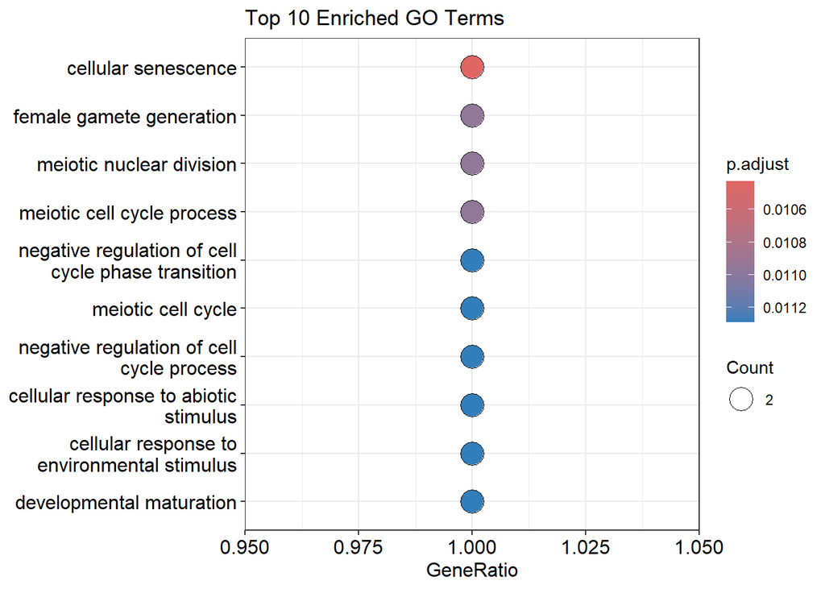

```r
# Install package
# BiocManager::install(c("enrichplot"))

# Load Library
library(enrichplot)
library(clusterProfiler)
library(ggplot2)

# Dotplot visualization for GO enrichment results
dotplot(ego, showCategory = 10) + ggtitle("Top 10 Enriched GO Terms")
```

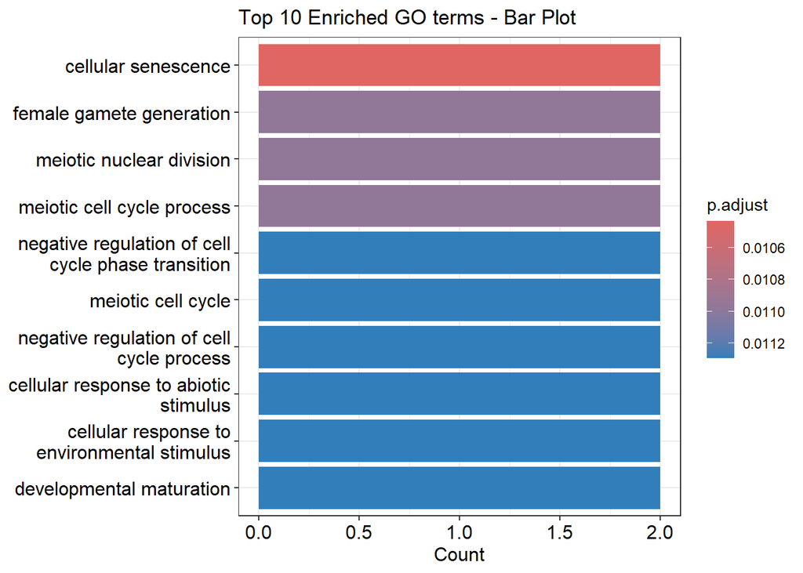

```r
# Barplot visualization
barplot(
  ego,
  showCategory = 10,
  drop = TRUE,
  x = "Count"
) +
  ggtitle("Top 10 Enriched GO terms - Bar Plot")
```

### 1. F. Interpreting Enrichment Results

Interpreting the results involes identifying significantly enriched terms and understanding their biological relevance. Consider factors like:

- The number of genes associated with each term.
- The adjusted p-values indicating statistical significance (commonly adjusted using the Benjamini-Hochberg method).
- The biological context of the terms in relation to your study.

Functional annotation and enrichment analysis are powerful tools in bioinformatics that facilitate the interpretation of gene expression data by linking gene lists to biological functions and pathways. By using R and Bioconductor packages like “biomaRt” and “clusterProfiler”, researchers can effectively uncover biologically relevant insights from their data. This chapter provided a foundational understanding of these processes, quipping you with the tools necessary to carry out your analyses.

## 2. Gene Ontology (GO) and Pathway Analysis with cluster Profiler.

Gene Ontology (GO) serve as a powerful framework for annotating genes across different species, making it easier to compare and interpret functional genomics data. Pathway analysis complements this by linking gene expression changes to biologically relevant pathways, facilitating insights into cellular mechanisms and disease processes.

In this chapter, we will explore how to leverage the “cluster Profiler” package in R for performing Gene Ontology and pathway analysis. The “cluster Profiler” package is widely recognized for its user-friendly syntax and adaptability to various types of input data, including gene lists derived from differential expression analyses or other high-throughput experiments.

### 2. A. Understanding Gene Ontology (GO)

Gene Ontology is organized into three main categories:

- **Biological Process (BP)**: Series of events accomplished by one or more molecular functions (e.g., cell division).
- **Molecular Function (MF)**: The biochemical activities of gene products (e.g., enzyme activity).
- **Cellular Component (CC)**: Locations within a cell where gene products are active (e.g., mitochondrion).

GO annotations provide valuable context, helping researchers interpret gene functions beyond mere sequence data.

### 2. B. Introduction to Pathway Analysis

Pathway analysis involves determining whether the genes in a specific list (e.g., differentially expressed genes) are enriched in certain biological pathways. Pathways can represent signalling cascades, metabolic pathways, and other interconnected systems of gene regulation and activity. This analysis helps in identifying which biological processes are statistically significant and provides insights into potential functional interactions.

### 2. C. Installing and Loading cluster Profiler

To get started with Gene Ontology and pathway analysis using cluster Profiler, you will first need to install the package. Ensure that R and Bioconductor are installed on your machine. You can do this by executing the following commands in your R environment.

#### 2. C. I. Installing cluster Profiler and org.Hs.eg.db

```r
# Install BiocManger if not already installed
# if (!require("BiocManager", quietly = TRUE))
#   install.packages("BiocManager")
# BiocManager::install(version = "3.22")

# Install "cluster Profiler" and "org.Hs.eg.db" for human gene anotations
# BiocManager::install(c("clusterProfiler", "org.Hs.eg.db"))
```

#### 2. C. II. Load cluster Profiler and org.Hs.eg.db

Next load the libraries

```r
# Load libraries
library(clusterProfiler)
library(org.Hs.eg.db) # Make sure to load specific organism annotation package
```

### 2. D. Performing GO Analysis

#### 2. D. I. Data preparation

Assuming you have a vector of gene symbols or Entrez IDs, you can use them for GO analysis. Let’s say we have a list of differentially expressed genes:

```r
# Example gene list
gene_list <- c("TP53", "BRCA1", "EGFR", "VEGFA", "IL6")
gene_list
```

```
## [1] "TP53"  "BRCA1" "EGFR"  "VEGFA" "IL6"
```

#### 2. D. II. Enriching GO Terms

To perform the enrichment analysis for GO terms, use the “enrichGO()” function:

```r
ego <- enrichGO(gene = gene_list,
                OrgDb = org.Hs.eg.db,
                keyType = "SYMBOL",
                ont = "BP", # Choose among "BP", "MF", "CC"
                pAdjustMethod = "BH",
                qvalueCutoff = 0.05,
                readable = TRUE)
ego
```

```
## #
## # over-representation test
## #
## #...@organism     Homo sapiens
## #...@ontology     BP
## #...@keytype      SYMBOL
## #...@gene     chr [1:5] "TP53" "BRCA1" "EGFR" "VEGFA" "IL6"
## #...pvalues adjusted by 'BH' with cutoff <0.05
## #...773 enriched terms found
## 'data.frame':    773 obs. of  12 variables:
##  $ ID            : chr  "GO:1902893" "GO:0061614" "GO:2000628" "GO:0010586" ...
##  $ Description   : chr  "regulation of miRNA transcription" "miRNA transcription" "regulation of miRNA metabolic process" "miRNA metabolic process" ...
##  $ GeneRatio     : chr  "4/5" "4/5" "4/5" "4/5" ...
##  $ BgRatio       : chr  "75/18860" "76/18860" "89/18860" "108/18860" ...
##  $ RichFactor    : num  0.0533 0.0526 0.0449 0.037 0.0101 ...
##  $ FoldEnrichment: num  201.2 198.5 169.5 139.7 37.9 ...
##  $ zScore        : num  28.3 28.1 26 23.5 13.6 ...
##  $ pvalue        : num  1.15e-09 1.21e-09 2.31e-09 5.06e-09 1.25e-08 ...
##  $ p.adjust      : num  6.78e-07 6.78e-07 8.59e-07 1.41e-06 2.78e-06 ...
##  $ qvalue        : num  1.46e-07 1.46e-07 1.85e-07 3.05e-07 6.01e-07 ...
##  $ geneID        : chr  "TP53/EGFR/VEGFA/IL6" "TP53/EGFR/VEGFA/IL6" "TP53/EGFR/VEGFA/IL6" "TP53/EGFR/VEGFA/IL6" ...
##  $ Count         : int  4 4 4 4 5 4 3 3 3 4 ...
## #...Citation
## S Xu, E Hu, Y Cai, Z Xie, X Luo, L Zhan, W Tang, Q Wang, B Liu, R Wang, W Xie, T Wu, L Xie, G Yu. Using clusterProfiler to characterize multiomics data. Nature Protocols. 2024, 19(11):3292-3320
```

#### 2. D. III. Visualizing GO Results

To visualize the enriched GO terms, you can employ various plotting functions provided by cluster Profiler. A common visualization is bar plot and dot plot:

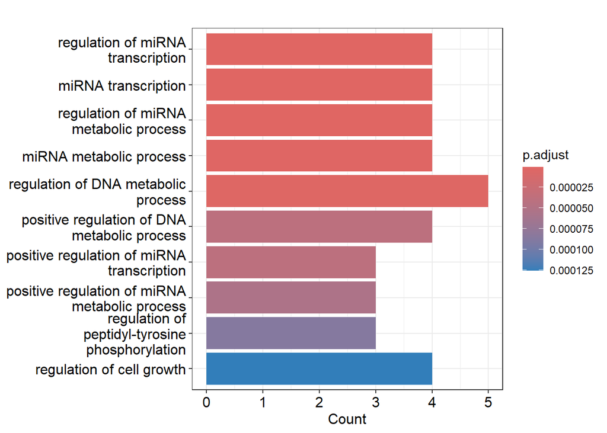

```r
# Bar plot of the top 10 enriched GO terms.
barplot(ego, showCategory = 10)
```

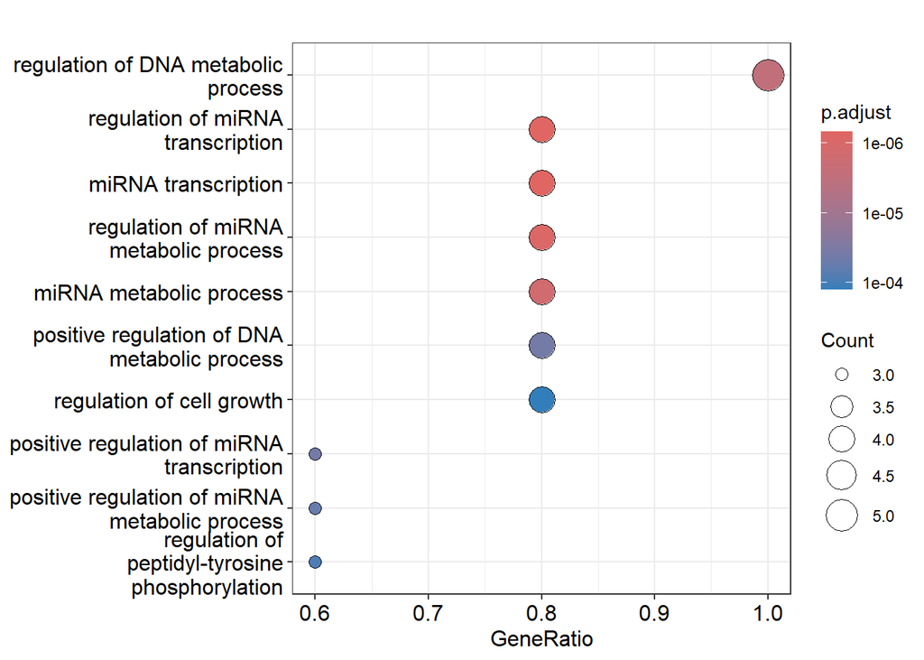

```r
# Dot plot
dotplot(ego, showCategory = 10)
```

These plots encapsulate the most significant GO terms, facilitating easier interpretation of results.

### 2. E. Pathway Analysis Using KEGG

The “cluster Profiler” package also supports pathway analysis, particularly with KEGG (Kyoto Encyclopedia of Genes and Genomes) pathways. To conduct a pathway enrichment analysis, we will use the “enrichKEGG()” function:

#### 2. E. I. Pathway analysis

```r
# Convert gene symbols to Entrez IDs (required for enrichKEGG)
gene_df <- bitr(gene_list,
                fromType = "SYMBOL",
                toType = "ENTREZID",
                OrgDb = org.Hs.eg.db)
# Extract Entrez IDs
entrez_ids <- gene_df$ENTREZID
entrez_ids
```

```
## [1] "7157" "672"  "1956" "7422" "3569"
```

```r
# Pathway enrichment analysis
kegg <- enrichKEGG(gene = entrez_ids,
                   organism = "hsa", # hsa for Homo sapiens
                   pAdjustMethod = "BH",
                   qvalueCutoff = 0.05)
```

```
## Reading KEGG annotation online: "https://rest.kegg.jp/link/hsa/pathway"...
```

```
## Reading KEGG annotation online: "https://rest.kegg.jp/list/pathway/hsa"...
```

```r
kegg
```

```
## #
## # over-representation test
## #
## #...@organism     hsa
## #...@ontology     KEGG
## #...@keytype      kegg
## #...@gene     chr [1:5] "7157" "672" "1956" "7422" "3569"
## #...pvalues adjusted by 'BH' with cutoff <0.05
## #...52 enriched terms found
## 'data.frame':    52 obs. of  14 variables:
##  $ category      : chr  "Environmental Information Processing" "Human Diseases" "Human Diseases" "Human Diseases" ...
##  $ subcategory   : chr  "Signal transduction" "Cancer: specific types" "Infectious disease: viral" "Cancer: specific types" ...
##  $ ID            : chr  "hsa04151" "hsa05219" "hsa05163" "hsa05212" ...
##  $ Description   : chr  "PI3K-Akt signaling pathway" "Bladder cancer" "Human cytomegalovirus infection" "Pancreatic cancer" ...
##  $ GeneRatio     : chr  "5/5" "3/5" "4/5" "3/5" ...
##  $ BgRatio       : chr  "362/9522" "41/9522" "227/9522" "77/9522" ...
##  $ RichFactor    : num  0.0138 0.0732 0.0176 0.039 0.0375 ...
##  $ FoldEnrichment: num  26.3 139.3 33.6 74.2 71.4 ...
##  $ zScore        : num  11.3 20.3 11.4 14.8 14.5 ...
##  $ pvalue        : num  7.73e-08 7.37e-07 1.54e-06 5.03e-06 5.64e-06 ...
##  $ p.adjust      : num  9.05e-06 4.31e-05 6.02e-05 1.19e-04 1.19e-04 ...
##  $ qvalue        : num  3.42e-06 1.63e-05 2.28e-05 4.49e-05 4.49e-05 ...
##  $ geneID        : chr  "7157/672/1956/7422/3569" "7157/1956/7422" "7157/1956/7422/3569" "7157/1956/7422" ...
##  $ Count         : int  5 3 4 3 3 4 3 3 3 3 ...
## #...Citation
## S Xu, E Hu, Y Cai, Z Xie, X Luo, L Zhan, W Tang, Q Wang, B Liu, R Wang, W Xie, T Wu, L Xie, G Yu. Using clusterProfiler to characterize multiomics data. Nature Protocols. 2024, 19(11):3292-3320
```

#### 2. E. II. Visualizing KEGG Results

Similar to GO analysis, the results can be visualized through plots:

```r
# Install Libraries
BiocManager::install(c("pathview", "png", "grid"))
# Load libraries
library(pathview)
library(png)
library(grid)

# View KEGG pathways
head(kegg)
```

```
##                                      category                     subcategory
## hsa04151 Environmental Information Processing             Signal transduction
## hsa05219                       Human Diseases          Cancer: specific types
## hsa05163                       Human Diseases       Infectious disease: viral
## hsa05212                       Human Diseases          Cancer: specific types
## hsa01521                       Human Diseases Drug resistance: antineoplastic
## hsa05206                       Human Diseases                Cancer: overview
##                ID                               Description GeneRatio  BgRatio
## hsa04151 hsa04151                PI3K-Akt signaling pathway       5/5 362/9522
## hsa05219 hsa05219                            Bladder cancer       3/5  41/9522
## hsa05163 hsa05163           Human cytomegalovirus infection       4/5 227/9522
## hsa05212 hsa05212                         Pancreatic cancer       3/5  77/9522
## hsa01521 hsa01521 EGFR tyrosine kinase inhibitor resistance       3/5  80/9522
## hsa05206 hsa05206                       MicroRNAs in cancer       4/5 320/9522
##          RichFactor FoldEnrichment    zScore       pvalue     p.adjust
## hsa04151 0.01381215       26.30387 11.250445 7.732342e-08 9.046840e-06
## hsa05219 0.07317073      139.34634 20.347393 7.366420e-07 4.309355e-05
## hsa05163 0.01762115       33.55771 11.379373 1.544111e-06 6.022031e-05
## hsa05212 0.03896104       74.19740 14.781425 5.026198e-06 1.188781e-04
## hsa01521 0.03750000       71.41500 14.496209 5.642600e-06 1.188781e-04
## hsa05206 0.01250000       23.80500  9.511307 6.096311e-06 1.188781e-04
##                qvalue                  geneID Count
## hsa04151 3.418509e-06 7157/672/1956/7422/3569     5
## hsa05219 1.628366e-05          7157/1956/7422     3
## hsa05163 2.275531e-05     7157/1956/7422/3569     4
## hsa05212 4.492019e-05          7157/1956/7422     3
## hsa01521 4.492019e-05          1956/7422/3569     3
## hsa05206 4.492019e-05      7157/672/1956/7422     4
```

```r
# Bar plot of enriched KEGG pathways
barplot(kegg, showCategory = 10)
# Pathway map visualization
pathview(gene.data = entrez_ids,
         pathway.id = "hsa04110",
         species = "hsa")
```

[output not shown]

```
## Info: Working in directory D:/Ajay Files/R Programming for Bioinformatics/Chapter 9
```

```
## Info: Writing image file hsa04110.pathview.png
```

```r
# Run Pathview (output is saved as PNG by default)
pv_out <- pathview(gene.data = entrez_ids,
                   pathway.id = "hsa04110",
                   species = "hsa",
                   out.suffix = "demo")
```

```
## Info: Working in directory D:/Ajay Files/R Programming for Bioinformatics/Chapter 9
```

```
## Info: Writing image file hsa04110.demo.png
```

[figure not shown]

```r
# Check output file name
# It follows the pattern: "hsa04110.demo.png"
img_file <- "hsa04110.demo.png"

# Read PNG image
img <- readPNG(img_file)

# Display in RStudio Plots pane
grid::grid.raster(img)
```

### 2. F. Interpreting Results

The results from both GO and pathway analyses provide insight into the biological significance of the gene sets. By identifying enriched terms and pathways, researchers can formulate hypotheses, generate new questions, and guide further validation experiments.

- **Biological Significance**: Reflect on how the enriched GO terms and pathways relate to the biological context of your research.
- **Gene Interactions**: Look at networks of genes and their interactions within enriched pathways to identify potential regulatory mechanisms.
- **Cross-Species Comparisons**: Use the GO framework to compare findings across different species and understanding evolutionary conservation of biological functions.

Gene Ontology and pathway analysis using the “clusterProfiler” package in R offers bioinformaticians a comprehensive toolkit for exploring the functional implications of gene expression data. Emphasizing the biological relevance of findings enhances our understanding of complex biological systems. As you advance your research, don’t hestitate to explore additional resources and methods in the ecosystem of R for bioinformatics, which continually evolves to meet the growing demands of high-throughput biological data analysis.

## 3. Interpreting Biological Significance of Genomic Data.

This chapter aims to guide you through the essential steps to interpret the biological significance of genomic data using R, showcasing various libraries, methodologies, and approaches.

### 3. A. Understanding Genomic Data

Genomic data can take various forms, including DNA sequences, gene expression profiles, mutation data, and epigenetic modifications. Each type of data provides insights into biological processes, disease mechanisms, and evolutionary relationships. Understanding the nature of the data and its sources is crucial in selecting the right analytical approaches.

#### 3. A. I. Types of Genomic Data

- **DNA Sequences**: The fundamental building blocks of life; they can be analyzed for polymorphisms, mutations and evolutionary divergence.
- **Gene Expression Data**: Quantifies the activity levels of genes, often produced from techniques like RNA-seq.
- **Variant Data**: Includes single nucleotide polymorphisms (SNPs), insertions, deletions, and structural variants that can be associated with phenotypic traits or diseases.
- **Epigenetic Data**: Explores chemical modifications to DNA and histones that regulate gene expression without altering the underlying sequence.

### 3. B. Setting Up the R Environment

Before delving into data analysis, it is necessary to set up a suitable R environment. This includes installing relevant packages designed for genomic data analysis.

#### 3. B. I. Installing Necessary Packages

```r
# Install BiocManger if not already installed
# if (!require("BiocManager", quietly = TRUE))
#   install.packages("BiocManager")
# BiocManager::install(version = "3.22")

# Install Packages
# BiocManager::install(c("GenomicRanges", "DESeq2", "edgeR", "ggplot2", "biomaRt"))
```

#### 3. B. II. Loading Libraries

```r
library(GenomicRanges)
library(DESeq2)
library(edgeR)
```

```r
library(ggplot2)
library(biomaRt)
```

### 3. C. Exploratory Data Analysis (EDA)

EDA helps to discern patterns, trends, and anomalies in genomic data. Visualization is an essential aspect of EDA, as it facilitates an intuitive understanding of complex data.

#### 3. C. I. Visualizing Data

Using ggplot2, we can create informative plots to visualize gene expression data or mutation frequencies.

```r
# Parameters
set.seed(42)  # reproducibility
n_genes <- 20000   # number of genes
n_samples <- 4     # 2 control, 2 treated
total_counts <- 1013912

# Simulate counts from a negative binomial distribution
raw_counts <- matrix(
  rnbinom(n_genes * n_samples, mu = 50, size = 1/0.2),  # mean=50, dispersion=0.2
  nrow = n_genes,
  ncol = n_samples
)

head(raw_counts)
```

```
##      [,1] [,2] [,3] [,4]
## [1,]   73   70   39   72
## [2,]   38   11   27   31
## [3,]   38   25   41   67
## [4,]   97   19   71   62
## [5,]   96   22   44   65
## [6,]   26   36   68   42
```

```r
# Scale counts so total sum matches exactly 1,013,912
scale_factor <- total_counts / sum(raw_counts)
scale_factor
```

```
## [1] 0.2533597
```

```r
counts_scaled <- round(raw_counts * scale_factor)
head(counts_scaled)
```

```
##      [,1] [,2] [,3] [,4]
## [1,]   18   18   10   18
## [2,]   10    3    7    8
## [3,]   10    6   10   17
## [4,]   25    5   18   16
## [5,]   24    6   11   16
## [6,]    7    9   17   11
```

```r
# Assign gene IDs
rownames(counts_scaled) <- paste0("Gene", seq_len(n_genes))
colnames(counts_scaled) <- c("control_rep1", "control_rep2", "treated_rep1", "treated_rep2")
head(counts_scaled)
```

```
##       control_rep1 control_rep2 treated_rep1 treated_rep2
## Gene1           18           18           10           18
## Gene2           10            3            7            8
## Gene3           10            6           10           17
## Gene4           25            5           18           16
## Gene5           24            6           11           16
## Gene6            7            9           17           11
```

```r
# Create sample metadata
colData <- data.frame(
  condition = factor(c("control", "control", "treated", "treated")),
  replicate = c(1, 2, 1, 2)
)
rownames(colData) <- colnames(counts_scaled)

head(counts_scaled)
```

```
##       control_rep1 control_rep2 treated_rep1 treated_rep2
## Gene1           18           18           10           18
## Gene2           10            3            7            8
## Gene3           10            6           10           17
## Gene4           25            5           18           16
## Gene5           24            6           11           16
## Gene6            7            9           17           11
```

```r
write.csv(counts_scaled, file = "D:/Ajay Files/R Programming for Bioinformatics/Chapter 9/gene_expression.csv")

# Example: Visualizing Gene Expression Data
gene_expression <- read.csv("gene_expression.csv")
head(gene_expression, n = 1)
```

```
##       X control_rep1 control_rep2 treated_rep1 treated_rep2
## 1 Gene1           18           18           10           18
```

```r
# Change X column to Genes
names(gene_expression)[names(gene_expression) == 'X'] <- 'Genes'
head(gene_expression, n = 1)
```

```
##   Genes control_rep1 control_rep2 treated_rep1 treated_rep2
## 1 Gene1           18           18           10           18
```

```r
# Load Library
library(tidyr)
# Conversion of wide data set to a long data set
gene_expression <- pivot_longer(gene_expression, cols = c("control_rep1", "control_rep2", "treated_rep1", "treated_rep2"),
                                names_to = "sample", values_to = "expression_level")
head(gene_expression, n =1)
```

```
## # A tibble: 1 × 3
##   Genes sample       expression_level
##   <chr> <chr>                   <int>
## 1 Gene1 control_rep1               18
```

```r
head(colData, n = 1)
```

```
##              condition replicate
## control_rep1   control         1
```

```r
gene_expression <- data.frame(Genes = gene_expression$Genes,
                              Condition = rep(colData$condition, times = 20000),
                              Replicate = rep(colData$replicate, times = 20000),
                              Sample = gene_expression$sample,
                              Expression_Level = gene_expression$expression_level)
head(gene_expression, n = 3)
```

```
##   Genes Condition Replicate       Sample Expression_Level
## 1 Gene1   control         1 control_rep1               18
## 2 Gene1   control         2 control_rep2               18
## 3 Gene1   treated         1 treated_rep1               10
```

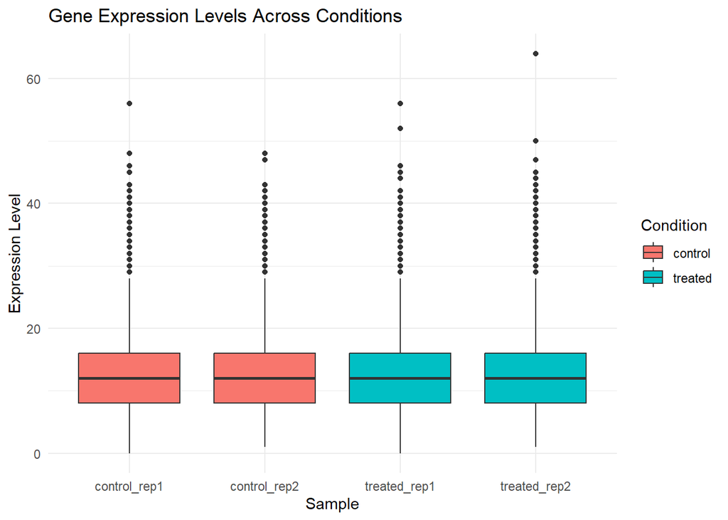

```r
ggplot(gene_expression, aes(x = Sample , y = Expression_Level, fill = Condition)) +
  geom_boxplot() +
  theme_minimal() +
  labs(title = "Gene Expression Levels Across Conditions",
       x = "Sample",
       y = "Expression Level",
       fill = "Condition")
```

### 3. D. Analyzing Genomic Data

#### 3. D. I. Differential Gene Expression Analysis

One of the most common tasks in genomic analysis is identifying genes that are differentially expressed under different conditions

##### 3. D. I. a Using DESeq2

```r
# Write simulated counts data into a CSV file
write.csv(counts_scaled, file = "D:/Ajay Files/R Programming for Bioinformatics/Chapter 9/counts.csv")

# Example: Visualizing Gene Expression Data
count_data <- read.csv("counts.csv", row.names = 1, check.names = FALSE)
head(count_data, n = 1)
```

```
##       control_rep1 control_rep2 treated_rep1 treated_rep2
## Gene1           18           18           10           18
```

```r
# Convert to numeric matrix
counts_mat <- as.matrix(count_data)

# Ensure numeric (avoid factors/characters)
storage.mode(counts_mat) <- "numeric"

# If counts were scaled and you need integers for DESeq2:
counts_mat <- round(counts_mat)

# Create DESeq2 object
dds <- DESeqDataSetFromMatrix(countData = counts_mat,
                              colData = colData,
                              design = ~ condition)
dds
```

```
## class: DESeqDataSet
## dim: 20000 4
## metadata(1): version
## assays(1): counts
## rownames(20000): Gene1 Gene2 ... Gene19999 Gene20000
## rowData names(0):
## colnames(4): control_rep1 control_rep2 treated_rep1 treated_rep2
## colData names(2): condition replicate
```

```r
# Run the DESeq analysis
dds <- DESeq(dds)
dds
```

```
## class: DESeqDataSet
## dim: 20000 4
## metadata(1): version
## assays(4): counts mu H cooks
## rownames(20000): Gene1 Gene2 ... Gene19999 Gene20000
## rowData names(22): baseMean baseVar ... deviance maxCooks
## colnames(4): control_rep1 control_rep2 treated_rep1 treated_rep2
## colData names(3): condition replicate sizeFactor
```

```r
results <- results(dds)
head(results, n = 20)
```

```
## log2 fold change (MLE): condition treated vs control
## Wald test p-value: condition treated vs control
## DataFrame with 20 rows and 6 columns
##         baseMean log2FoldChange     lfcSE        stat    pvalue      padj
##        <numeric>      <numeric> <numeric>   <numeric> <numeric> <numeric>
## Gene1   15.70739      -0.371675  0.782615   -0.474914  0.634848  0.997025
## Gene2    6.86872       0.199305  0.994093    0.200489  0.841098  0.997025
## Gene3   10.53944       0.746257  0.872152    0.855651  0.392191  0.997025
## Gene4   15.70376       0.174470  0.863950    0.201945  0.839960  0.997025
## Gene5   13.98251      -0.159566  0.867633   -0.183910  0.854084  0.997025
## ...          ...            ...       ...         ...       ...       ...
## Gene16  13.27179     0.31631812  0.861148  0.36732125 0.7133794  0.997025
## Gene17   9.58365    -1.00834367  0.892016 -1.13040973 0.2583036  0.997025
## Gene18   6.38134    -0.00645339  1.016408 -0.00634921 0.9949341  0.997025
## Gene19  17.42035     1.44524226  0.800099  1.80632975 0.0708668  0.997025
## Gene20  13.98257     0.34656442  0.823512  0.42083699 0.6738741  0.997025
```

##### 3. D. I. b. Filtering Results

```r
sig_results <- rownames(results)[which(results$padj < 0.998 & abs(results$log2FoldChange)> 2)]
sig_results
```

```
##   [1] "Gene100"   "Gene316"   "Gene319"   "Gene358"   "Gene515"   "Gene636"
##   [7] "Gene957"   "Gene1165"  "Gene1409"  "Gene1609"  "Gene1735"  "Gene2216"
##  [13] "Gene2337"  "Gene2536"  "Gene2621"  "Gene2780"  "Gene2808"  "Gene3013"
##  [19] "Gene3158"  "Gene3301"  "Gene3851"  "Gene4078"  "Gene4336"  "Gene4351"
##  [25] "Gene4522"  "Gene4944"  "Gene4954"  "Gene5025"  "Gene5053"  "Gene5311"
##  [31] "Gene5707"  "Gene5873"  "Gene5973"  "Gene5974"  "Gene6051"  "Gene6409"
##  [37] "Gene6439"  "Gene6631"  "Gene6674"  "Gene6835"  "Gene6913"  "Gene6931"
##  [43] "Gene6932"  "Gene7083"  "Gene7200"  "Gene7273"  "Gene7415"  "Gene7583"
##  [49] "Gene7620"  "Gene7867"  "Gene7884"  "Gene8255"  "Gene8302"  "Gene8682"
##  [55] "Gene8707"  "Gene9014"  "Gene9099"  "Gene9648"  "Gene9758"  "Gene9926"
##  [61] "Gene9954"  "Gene10247" "Gene10339" "Gene10425" "Gene10943" "Gene11030"
##  [67] "Gene11031" "Gene11059" "Gene11335" "Gene11795" "Gene11900" "Gene11910"
##  [73] "Gene12236" "Gene12247" "Gene12277" "Gene12278" "Gene12642" "Gene12663"
##  [79] "Gene12858" "Gene12896" "Gene12937" "Gene13032" "Gene13116" "Gene13267"
##  [85] "Gene13402" "Gene14159" "Gene14277" "Gene14482" "Gene15007" "Gene15329"
##  [91] "Gene15542" "Gene15653" "Gene15848" "Gene15946" "Gene16299" "Gene16805"
##  [97] "Gene17101" "Gene17121" "Gene17456" "Gene17504" "Gene17572" "Gene17714"
## [103] "Gene17878" "Gene17968" "Gene18185" "Gene18218" "Gene18291" "Gene18324"
## [109] "Gene18636" "Gene18669" "Gene18804" "Gene19132" "Gene19662" "Gene19718"
## [115] "Gene19886"
```

#### 3. D. II Enrichment Analysis

Interpreting the biological significance of differentially expressed genes often involves determining if there are specific biological pathways or functions over-represented in the gene list.

##### 3. D. II. a. Gene Ontology (GO) Enrichment (not relevant for simulated data)

Using the biomaRt package, researchers can retrive GO annotations and perform enrichment analysis.

```r
# Get GO terms for significant genes
# gene_ids <- rownames(sig_results)

# gene_go <- getBM(attributes = c("ensembl_gene_id", "go_id", "name_1006"),
#                  filters = "ensembl_gene_id",
#                  values = "gene_ids",
#                  mart = useMart("ensembl"))
```

#### 3. D. III. Pathway Analysis (not relevant for simulated data)

Using packages like clusterProfiler, researchers can explore pathways that are significantly impacted by their findings.

```r
# Load library
# library(clusterProfiler)

# Using KEGG for pathway analysis
# kk <- enrichKEGG(gene = gene_ids, organism = "hsa")
# dotplot(kk)
```

### 3. E. Visualization of Results

Visualization of genomic data analysis results is crucial for interpreting and communicating findings.

#### 3. E. I. Heat maps

Identifying clusters of co-expressed genes can be effectively visualized using heat maps.

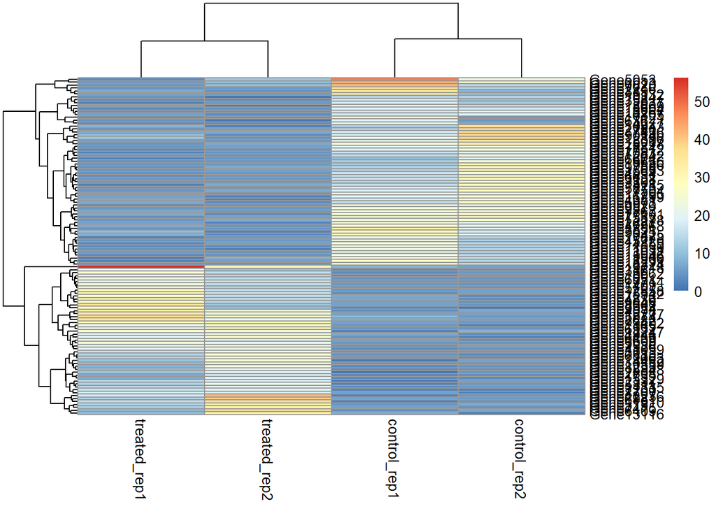

```r
# Load Library
library(pheatmap)

# Heat map
pheatmap(assay(dds)[sig_results,], cluster_rows = TRUE, cluster_cols = TRUE)
```

#### 3. E. II. Volcano Plots

A volcano plot helps to visualize the significance and magnitude of changes in a single plot

```r
volcano_data <- as.data.frame(results)
head(volcano_data)
```

```
##        baseMean log2FoldChange     lfcSE       stat    pvalue      padj
## Gene1 15.707394     -0.3716747 0.7826148 -0.4749139 0.6348483 0.9970251
## Gene2  6.868717      0.1993048 0.9940930  0.2004891 0.8410981 0.9970251
## Gene3 10.539440      0.7462572 0.8721516  0.8556508 0.3921910 0.9970251
## Gene4 15.703764      0.1744704 0.8639498  0.2019451 0.8399597 0.9970251
## Gene5 13.982514     -0.1595661 0.8676328 -0.1839097 0.8540843 0.9970251
## Gene6 10.801521      0.8006935 0.8585545  0.9326065 0.3510232 0.9970251
```

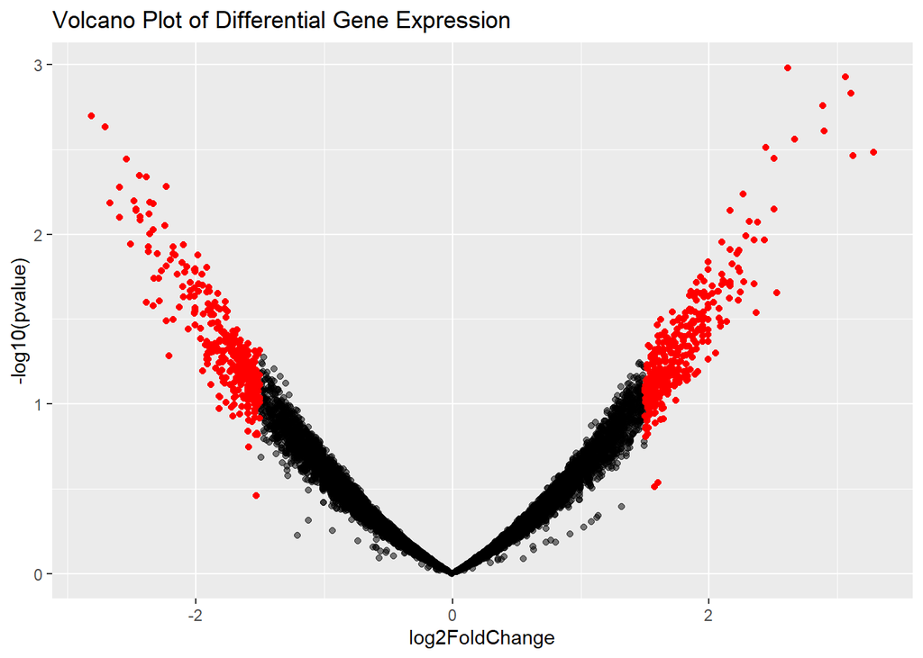

```r
ggplot(volcano_data, aes(x = log2FoldChange, y = -log10(pvalue))) +
  geom_point(alpha = 0.5, size = 1.5) +
  geom_point(data = subset(volcano_data, padj < 0.998 & abs(log2FoldChange) > 1.5), color = "red") +
  labs(title = "Volcano Plot of Differential Gene Expression")
```

Interpreting the biological significance of genomic data is a complex yet rewarding endeavor that provides crucial insights into biological processes. Leveraging the power of R, this chapter has presented a structured approach to genomic data analysis - from data preparation and exploratory analysis to advanced methods for differential expression and enrichment analysis. By applying these techniques and tools, researchers can uncover the layers of complexity within genomic data, leading to greater understanding and advancement in the fields of biology and medicine.

```r
Sys.Date()
```

```
## [1] "2026-01-18"
```